# Regresja i analiza wariancji - Laboratorium 1

Regresja liniowa wieloraka - wprowadzenie

Adrian Kowalski

Politechnika Krakowska

# Model regresji liniowej wielorakiej

Do tej pory rozważaliśmy model regresji liniowej prostej
$$y_i = \beta_0 + \beta_1 x_i + \epsilon_i.$$
W rzeczywistości występuje bardzo mało zależności, które da się opisać za pomocą dokładnie jednej zmiennej objaśniającej. Uogólnimy nasze podejście do regresji liniowej wprowadzając nowe zmienne objaśniające i sprowadzając model do postaci.
$$y_i = \beta_0 + \beta_1 x_{i1} + \beta_2 x_{i2}
+ \dots + \beta_k x_{ik} + \varepsilon_i.$$
Gdzie $\varepsilon_i$ nadal będą zmiennymi losowymi o rozkładzie $N(0,\sigma^2)$ dla pewnej stałej wariancji $\sigma^2$. Wszelkie pozostałe założenia modelu, które poczyniliśmy przy regresji liniowej prostej pozostają, dojdzie natomiast dodatkowe założenie wynikające z postaci współczynników. Standardowo będziemy oznaczać tak jak poprzednio
$$\hat{y_i} = \beta_0 + \beta_1 x_{i1} + \beta_2
x_{i2} + \dots + \beta_k x_{ik}$$

# Macierzowa postać modelu regresji

Podobnie jak w przypadku regresji liniowej prostej będziemy chcieli zminimalizować błąd średniokwadratowy naszego estymatora. W tym wypadku natomiast przybiera on nieco inną postać
$$MSE = \frac{\sum_{i=1}^n \varepsilon_i^2}{n - (k + 1)} =
\frac{\sum_{i=1}^n (y_i - \hat{y}_i )^2}{n - (k+1)} = \frac{\sum_{i=1}^n
(y_i - \beta_0 - \beta_1x_{i1} - \dots - \beta_k x_{ik} )^2}{n -
(k+1)}$$
W tym celu spojrzymy na nasz model z nieco innej perspektywy. Spójrzmy jeszcze raz na równanie regresji
$$y_i = \beta_0 + \beta_1 x_{i1} + \beta_2 x_{i2}
+ \dots + \beta_k x_{ik} + \varepsilon_i.$$
Dla dowolnego ustalonego $i$ możemy je zapisać w formie
$$y_i = [1, x_{i1}, x_{i2}, \dots,
x_{ik}]\left[\begin{array}{c} \beta_0 \\ \beta_1 \\ \dots \\ \beta_k
\end{array} \right] + \varepsilon_i.$$

Dzięki tej formie zapisu możemy spojrzeć teraz na model całościowo, uwzględniając na raz wszystkie dane.
$$\left[\begin{array}{c} y_1 \\ y_2 \\ \dots \\ y_n
\end{array} \right] = \left[\begin{array}{c} 1 \; x_{11} \; \dots x_{1k}
\\ 1 \; x_{21} \; \dots \; x_{2k} \\ \dots \\ 1 \; x_{n1} \; \dots \;
x_{nk} \end{array} \right] \left[\begin{array}{c} \beta_0 \\ \beta_1 \\
\dots \\ \beta_k \end{array} \right] + \left[\begin{array}{c}
\varepsilon_1 \\ \varepsilon_2 \\ \dots \\ \varepsilon_n \end{array}
\right].$$
Od tej pory będziemy używać zapisu skrótowego
$$\boldsymbol{y} = \left[\begin{array}{c} y_1 \\
y_2 \\ \dots \\ y_n \end{array} \right]$$
$$\boldsymbol{X} = \left[\begin{array}{c} 1 \;
x_{11} \; \dots x_{1k} \\ 1 \; x_{21} \; \dots \; x_{2k} \\ \dots \\ 1
\; x_{n1} \; \dots \; x_{nk} \end{array} \right]$$

$$\boldsymbol{\beta} =
\left[\begin{array}{c} \beta_0 \\ \beta_1 \\ \dots \\ \beta_k
\end{array} \right]$$
$$\boldsymbol{\varepsilon} = \left[\begin{array}{c} \varepsilon_1 \\
\varepsilon_2 \\ \dots \\ \varepsilon_n \end{array} \right]$$
Biorąc pod uwagę wprowadzone oznaczenia, nasz model w skrótowej formie przyjmuje postać
$$\boldsymbol{y} =
\boldsymbol{X}\boldsymbol{\beta} + \boldsymbol{\varepsilon}.$$

# Wyznaczenie współczynników modelu liniowego

W celu wyznaczenia ogólnego wzoru na współczynniki modelu regresji liniowej wielorakiej możemy postąpić tak jak poprzednio, po przez minimalizacje błędu średniokwadratowego. Takie rozumowanie prowadzi chociażby autor [tutaj](http://home.iitk.ac.in/~shalab/regression/Chapter3-Regression-MultipleLinearRegressionModel.pdf). Można też wyprowadzić ten wzór za pomocą rozkładu SVD macierzy tak jak robią to autorzy [tutaj](http://databookuw.com/databook.pdf). My skorzystamy ze wzoru na tzw. (lewą) pseudo-odwrotność Moora-Penrose’a
$$X^\dagger = (X^TX)^{-1}X^T$$
Jej zastosowanie daje nam wzór na współczynniki
$$(X^TX)^{-1}X^T\boldsymbol{y} = \beta.$$
Wstawiamy ten wzór do modelu i otrzymujemy
$$\hat{y} = X(X^TX)^{-1}X^T\boldsymbol{y}$$

Macierz
$$H := X(X^TX)^{-1}X^T$$
nazywa się czasem hat matrix.

# Założenia modelu regresji wielorakiej

Zauważmy, że chociażby z faktu, że wykorzystujemy macierz $(XX^T)^{-1}$, ta odwrotność musi istnieć. Musimy zatem dołożyć kolejne założenie do naszej klasycznej listy założeń, mówiące o pełnym rzędzie kolumnowym macierzy $X$, co przekłada się po prostu na brak struktury zależności między zmiennymi objaśniającymi $x_1, x_2, \dots, x_k$. Podsumowując, wykorzystując zapis macierzowy, nasze założenia to

- liniowa zależność między zmienną objaśnianą, a objaśniającą postaci $\boldsymbol{y} = \boldsymbol{X}\boldsymbol{\beta} + \boldsymbol{\varepsilon}$,
- wektor losowy $\varepsilon$ ma średnią $\boldsymbol{0}$,
- wektor losowy $\varepsilon$ ma macierz kowariancji postaci $\sigma^2 \boldsymbol{I}$, gdzie $\sigma^2$ to pewna liczba rzeczywista,
- zmienne losowe $\varepsilon_i, \varepsilon_j$ są ze sobą niezależne, dla różnych $i,j$,
- wektor losowy $\varepsilon$ ma wielowymiarowy rozkład normalny $N(0, \sigma^2 \boldsymbol{I})$,
- rzadna ze zmiennych objaśniających nie jest kombinacją liniową pozostałych, innymi słowy, zmienne objaśniające są liniowo niezależne, a macierz $X$ jest pełnego rzędu kolumnowego.

O jakości estymatora, który wyznaczyliśmy w poprzednim rozdziale w sytuacji, gdy powyższe założenia są spełnione mówi twierdzenie [Gaussa-Markowa](https://en.wikipedia.org/wiki/Gauss%E2%80%93Markov_theorem).

# Współczynnik determinacji $R^2$.

Podobnie jak w przypadku regresji liniowej prostej, możemy w celu oceny jakości modelu skorzystać z współczynnika determinacji $R^2$. Ma on niestety poważną wadę w przypadku regresji liniowej wielorakiej. Przypomnijmy

$$R^2 = 1 - \frac{\sum_{i=1}^n
\varepsilon_i^2}{\sum_{i=1}^n(y_i - \overline{y})^2}.$$

Dodanie kolejnej zmiennej do modelu nigdy nie podniesie sumy kwadratów reszt, może ją tylko zmniejszyć lub nie zmienić. Zatem $R^2$ będzie większe im więcej zmiennych dodamy do modelu, co nie koniecznie będzie świadczyć o większej jakości modelu. Aby z tym walczyć wprowadzamy tzw. skorygowane $R^2$ (adjusted $R^2$ dane wzorem
$$R^2 = 1 - \frac{n - 1}{n - (k+1)}(1 - R^2).$$

Skorygowane $R^2$ bierze pod uwagę jakość modelu i ilość zmiennych objaśniających, więc może być używane do porówynywania różnych modeli.

# Statystyka F

Wywołując summary() na danym modelu regresji liniowej otrzymujemy również wartość statystyki testowej $F$ dla tego modelu. Statystyka ta jest ściśle związana z analizą wariancji i będziemy o niej jeszcze mówić, natomiast warto teraz wspomnieć o hipotezach testu, który ta statystyka wykonuje.
$$\begin{array}{ll} H_0: &
\beta_1 = \beta_2 = \dots = \beta_k = 0 \\ H_1: & \exists_{k}
\; \beta_k \neq 0 \end{array}$$
Innymi słowy, wysoka $p$-wartość testu $F$ świadczy o tym, że nasz model ma wyłącznie zerowe współczynniki.

# Ćwiczenie: Model wyceny używanych aut

Skorzystamy z danych [CARS DATASET (Audi, BMW, Ford, Hyundai, Skoda, VW)](https://www.kaggle.com/aishwaryamuthukumar/cars-dataset-audi-bmw-ford-hyundai-skoda-vw). Na podstawie tych danych zbudujemy różne modele regresji liniowej wielorakiej i porównamy je między sobą przy pomocy skorygowanego $R^2$.

```r
library(tidyverse)
cars <- readr::read_csv('cars_dataset.csv')
cars <- cars %>% dplyr::mutate(year = 2022 - year) %>% dplyr::rename(age = year)
cars_sample <- dplyr::sample_n(cars, 1000)
cars_sample <- cars_sample %>% mutate(random_col = rnorm(1000, mean = 3, sd = 0.5))
head(cars_sample)
```

| model | age | price | transmission | mileage | fuelType | tax | mpg | engineSize | Make | random_col |
| --- | --- | --- | --- | --- | --- | --- | --- | --- | --- | --- |
| A4 | 3 | 27695 | Semi-Auto | 1666 | Diesel | 145 | 47.9 | 2.0 | audi | 3.358020 |
| Fiesta | 9 | 6800 | Manual | 32638 | Petrol | 30 | 54.3 | 1.2 | Ford | 3.362831 |
| 4 Series | 3 | 22446 | Automatic | 10164 | Diesel | 145 | 65.7 | 2.0 | BMW | 3.459770 |
| 3 Series | 5 | 20962 | Semi-Auto | 30607 | Diesel | 160 | 51.4 | 3.0 | BMW | 3.265211 |
| Fiesta | 5 | 8498 | Manual | 28637 | Diesel | 0 | 78.5 | 1.5 | Ford | 2.830328 |
| Ka+ | 4 | 9400 | Manual | 4763 | Petrol | 145 | 57.7 | 1.2 | Ford | 2.400328 |

```r
cars_sample <- cars_sample %>% dplyr::filter((fuelType!='Hybrid')&(fuelType!='Other')&(fuelType!='Electric'))
```

```r
cars_model <- lm(price ~ age, data = cars_sample)
summary(cars_model)
```

```
Call:
lm(formula = price ~ age, data = cars_sample)

Residuals:
   Min     1Q Median     3Q    Max
-12618  -5198  -1031   3468  64390

Coefficients:
            Estimate Std. Error t value Pr(>|t|)
(Intercept)  27095.5      618.3   43.82   <2e-16 ***
age          -2195.7      116.6  -18.83   <2e-16 ***
---
Signif. codes:  0 ‘***’ 0.001 ‘**’ 0.01 ‘*’ 0.05 ‘.’ 0.1 ‘ ’ 1

Residual standard error: 7432 on 949 degrees of freedom
Multiple R-squared:  0.272, Adjusted R-squared:  0.2712
F-statistic: 354.5 on 1 and 949 DF,  p-value: < 2.2e-16
```

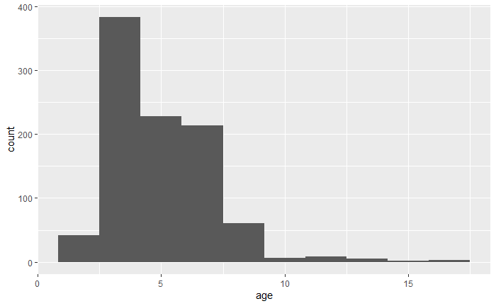

```r
ggplot(cars_sample, aes(x = age)) + geom_histogram(bins = 10)
```

```r
cars_model <- lm(price ~ log(age), data=cars_sample)
summary(cars_model)
```

```
Call:
lm(formula = price ~ log(age), data = cars_sample)

Residuals:
   Min     1Q Median     3Q    Max
-16447  -4632   -854   3424  63371

Coefficients:
            Estimate Std. Error t value Pr(>|t|)
(Intercept)  35399.4      916.3   38.63   <2e-16 ***
log(age)    -12627.3      588.4  -21.46   <2e-16 ***
---
Signif. codes:  0 ‘***’ 0.001 ‘**’ 0.01 ‘*’ 0.05 ‘.’ 0.1 ‘ ’ 1

Residual standard error: 7147 on 949 degrees of freedom
Multiple R-squared:  0.3268,    Adjusted R-squared:  0.326
F-statistic: 460.6 on 1 and 949 DF,  p-value: < 2.2e-16
```

```r
cars_model <- lm(price ~ log(age)+mpg, data=cars_sample)
summary(cars_model)
```

```
Call:
lm(formula = price ~ log(age) + mpg, data = cars_sample)

Residuals:
   Min     1Q Median     3Q    Max
-14160  -3810   -764   3416  53634

Coefficients:
            Estimate Std. Error t value Pr(>|t|)
(Intercept) 50668.26    1132.25   44.75   <2e-16 ***
log(age)    -9473.54     530.81  -17.85   <2e-16 ***
mpg          -368.71      19.73  -18.69   <2e-16 ***
---
Signif. codes:  0 ‘***’ 0.001 ‘**’ 0.01 ‘*’ 0.05 ‘.’ 0.1 ‘ ’ 1

Residual standard error: 6113 on 948 degrees of freedom
Multiple R-squared:  0.508, Adjusted R-squared:  0.5069
F-statistic: 489.4 on 2 and 948 DF,  p-value: < 2.2e-16
```

```r
summary(lm(price ~ log(age)+random_col, data=cars_sample))
```

```
Call:
lm(formula = price ~ log(age) + random_col, data = cars_sample)

Residuals:
   Min     1Q Median     3Q    Max
-16391  -4666   -855   3403  63349

Coefficients:
             Estimate Std. Error t value Pr(>|t|)
(Intercept)  35111.38    1665.15  21.086   <2e-16 ***
log(age)    -12631.30     588.99 -21.446   <2e-16 ***
random_col      97.79     471.98   0.207    0.836
---
Signif. codes:  0 ‘***’ 0.001 ‘**’ 0.01 ‘*’ 0.05 ‘.’ 0.1 ‘ ’ 1

Residual standard error: 7151 on 948 degrees of freedom
Multiple R-squared:  0.3268,    Adjusted R-squared:  0.3254
F-statistic: 230.1 on 2 and 948 DF,  p-value: < 2.2e-16
```

```r
cars_model <- lm(price ~ log(age)+mpg+engineSize, data=cars_sample)
summary(cars_model)
```

```
Call:
lm(formula = price ~ log(age) + mpg + engineSize, data = cars_sample)

Residuals:
   Min     1Q Median     3Q    Max
-12493  -2472    -62   2127  34553

Coefficients:
             Estimate Std. Error t value Pr(>|t|)
(Intercept)  27844.32    1052.16   26.46   <2e-16 ***
log(age)    -11797.66     372.98  -31.63   <2e-16 ***
mpg           -152.47      15.16  -10.06   <2e-16 ***
engineSize    8905.04     275.21   32.36   <2e-16 ***
---
Signif. codes:  0 ‘***’ 0.001 ‘**’ 0.01 ‘*’ 0.05 ‘.’ 0.1 ‘ ’ 1

Residual standard error: 4215 on 947 degrees of freedom
Multiple R-squared:  0.7663,    Adjusted R-squared:  0.7656
F-statistic:  1035 on 3 and 947 DF,  p-value: < 2.2e-16
```

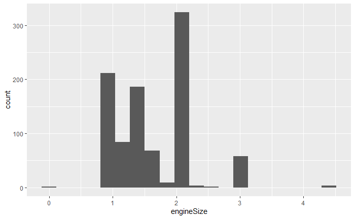

```r
ggplot(cars_sample, aes(x=engineSize)) + geom_histogram(bins = 20)
```

```r
cars_model <- lm(price ~ log(age)+mpg+engineSize+mileage, data=cars_sample)
summary(cars_model)
```

[output not shown]

```r
round(cor(cars_sample[,c(2,5,7,8,9)]),2)
```

```
             age mileage   tax   mpg engineSize
age         1.00    0.76 -0.21  0.21       0.07
mileage     0.76    1.00 -0.19  0.25       0.15
tax        -0.21   -0.19  1.00 -0.60       0.33
mpg         0.21    0.25 -0.60  1.00      -0.41
engineSize  0.07    0.15  0.33 -0.41       1.00
```

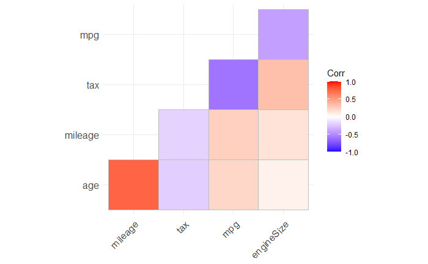

```r
library(ggcorrplot)
ggcorrplot(cor(cars_sample[,c(2,5,7,8,9)]), type='lower')
```

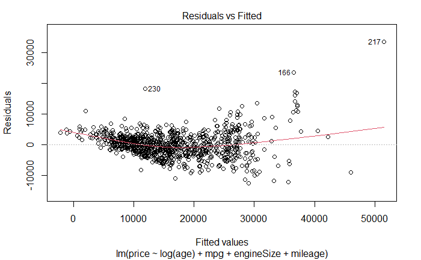

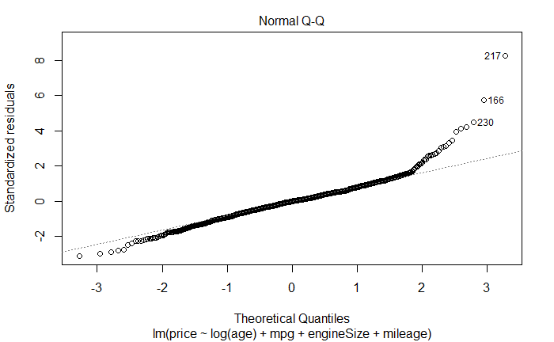

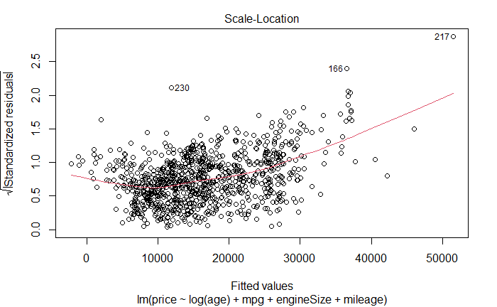

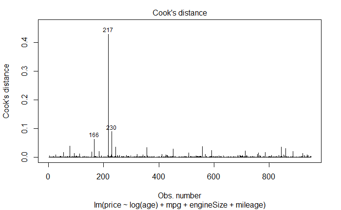

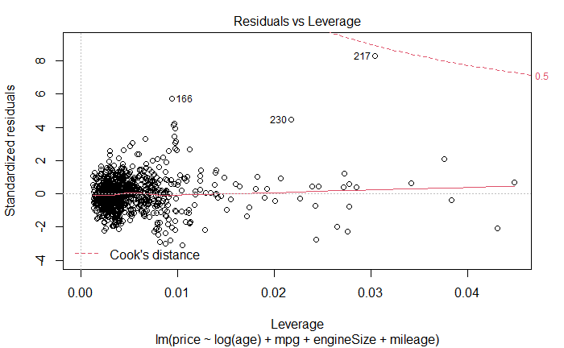

```r
plot(cars_model, which=1:5)
```